# Valores perdidos

```python
import pandas as pd

df = pd.read_csv("Data_demo.csv")
df.head()
```

|  | ID | Age | Aspiration | Price | NPS | Index.True | Sex | duration |
| --- | --- | --- | --- | --- | --- | --- | --- | --- |
| 0 | 1 | 20.0 | 1.0 | 15.0 | 0.0 | 98.0 | 0.0 | 150.0 |
| 1 | 2 | 22.0 | 2.0 | 18.0 | 1.0 | 100.0 | 1.0 | 154.0 |
| 2 | 3 | 24.0 | NaN | NaN | 2.0 | 102.0 | 0.0 | 158.0 |
| 3 | 4 | NaN | 4.0 | 14.0 | 3.0 | 104.0 | 1.0 | 162.0 |
| 4 | 5 | 28.0 | 5.0 | 20.0 | 4.0 | 106.0 | 0.0 | 166.0 |

```python
df.info()
```

```
<class 'pandas.core.frame.DataFrame'>
RangeIndex: 40 entries, 0 to 39
Data columns (total 8 columns):
 #   Column      Non-Null Count  Dtype
---  ------      --------------  -----
 0   ID          40 non-null     int64
 1   Age         33 non-null     float64
 2   Aspiration  34 non-null     float64
 3   Price       36 non-null     float64
 4   NPS         36 non-null     float64
 5   Index.True  28 non-null     float64
 6   Sex         37 non-null     float64
 7   duration    32 non-null     float64
dtypes: float64(7), int64(1)
memory usage: 2.6 KB
```

El siguiente paso consiste en conocer el número de missing values que hay en cada variable. La manera más sencilla para ello consiste en usar función isnull de Pandas, que devuelve True cuando se trata de un valor perdido y False en caso contrario, junto con la función sum para saber cuántos valores perdidos hay en cada columna. Veamos como funciona en el siguiente código:

```python
# Identificamos el número de missing values en cada columna
df.isnull().sum()
```

```
ID             0
Age            7
Aspiration     6
Price          4
NPS            4
Index.True    12
Sex            3
duration       8
dtype: int64
```

Podemos observar que la variable Age tiene 7 valores perdidos. Aspiration, Price y NPS cuentan con 6, 4 y 4 missing values. Index.True tiene 12 valores peridos, y finalmente Sex y Duration cuentan con 3 y 8 valores perdios. Otra forma de visualizar los missing values es utilizando un gráfico de mapas de calor que nos proporciona la librería seaborn como podéis ver a continuación:

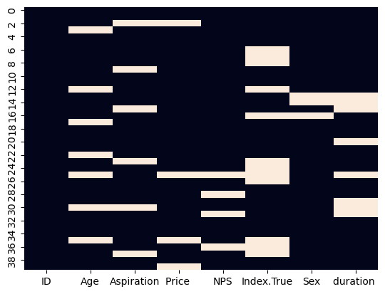

```python
import seaborn as sns

# Identificamos los missing values visualmente
sns.heatmap(df.isnull(), cbar=False)
```

Las marcas blancas del anterior gráfico representan los valores perdidos. Mediante este gráfico es más fácil encontrar patrones y vínculos existentes entre los missing values en las diferentes variables.

Una vez sabemos los valores perdidos que hay en las variables y están identificadas correctamente en el Dataframe, es hora de ocuparnos de ellos mediante su eliminación o imputación.

# Eliminación de valores perdidos

En primer lugar explicaremos como eliminar estos valores perdidos en Python. Esta opción no es recomendable para conjuntos de datos pequeños o con un alto porcentaje de valores perdidos. Dicho esto y si estamos seguros de que queremos eliminar estos valores, tan solo tenemos que usar la función dropna que nos proporciona Pandas.

Así, podemos, por ejemplo, eliminar las observaciones que contengan valores perdidos en todas las columnas ajustando el argumento how a 'all' (how='all') o mantener sólo aquellas con al menos 3 valores que no sean missing values (thresh=3). Para este caso, le vamos a definir en qué columnas buscar los valores perdidos y para ello usamos el parámetro subset:

NOTA: Vamos a eliminar Age y Aspiration sólo a modo de ejemplo.

```python
# Eliminamos las filas con missing values en Age o Aspiration

df.dropna(subset=["Age", "Aspiration"], inplace=True)

# Comprobamos que se han eliminado
print("valores perdidos en Age: " +
      str(df["Age"].isnull().sum()))
print("valores perdidos en Aspiration: " +
      str(df['Aspiration'].isnull().sum()))
```

```
valores perdidos en Age: 0
valores perdidos en Aspiration: 0
```

# Imputación de los valores perdidos

Hay dos aproximaciones comúnmente usadas para la imputación de los valores perdidos.

La primera técnica consiste en rellenar estos valores con la media (o mediana) de los datos de la variable en el caso de que se trate de una variable numérica. Para el caso de las variables categóricas imputamos los valores perdidos con la moda de la variable.

Pandas nos ofrece una función (fillna) para realizar esta imputación de manera sencilla. A continuación podéis ver como imputamos la variable numérica Index.True con la media y la variable categórica NPS con el valor mas frecuente:

```python
# Imputamos la variable description con la media
df['Index.True'].fillna(df['Index.True'].mean(), inplace=True)
print("valores perdidos en Index.True: " +
      str(df['Index.True'].isnull().sum()))

# Imputamos la variable num-of-doors con la moda
df['NPS'].fillna(df['NPS'].mode()[0], inplace=True)
print("Valores perdidos en NPS: " +
      str(df['NPS'].isnull().sum()))
```

```
valores perdidos en Index.True: 0
Valores perdidos en NPS: 0
```

Para este ejemplo práctico hemos calculado la media/moda de todos los datos. Sin embargo, en un ejemplo real y para evitar la fuga de datos (data leakage en inglés), es importante dividir los datos en datos de entrenamiento y datos de test, calcular la media/moda únicamente de los datos de entrenamiento y aplicarla a los datos de prueba.

Otra técnica más avanzada consiste en el uso de modelos predictivos para estimar los valores perdidos. Un modelo no paramétrico muy popular para estos casos es el k-nearest neighbors, donde se estima el valor perdido como la media (en el caso de las variables numéricas) de los valores de los k vecinos u observaciones mas cercanos. Asimismo, para las variables categóricas, se utiliza las clase mayoritaria de entre los k mas cercanos.

La librería scikit-learn nos proporciona la clase KNNImputer para hacer uso de este modelo en la imputación de missing values. Esta clase usa por defecto la distancia minkowsky, pero podemos elegir la que prefiramos modificando el parámetro metric. Asimismo, también podemos elegir el número de vecinos con el argumento n_neighbors y en esta ocasión usaremos 5. Podeís ver en el siguiente código como utilizamos este método para imputar los valores perdidos en la variable Sex:

```python
from sklearn.impute import KNNImputer

# Construimos el modelo
imputer = KNNImputer(n_neighbors=5, weights="uniform")

# Ajustamos el modelo e imputamos los missing values
imputer.fit(df[["Sex"]])
df["Sex"] = imputer.transform(df[["Sex"]]).ravel()

print("Valores perdidos en Sex: " +
      str(df['Sex'].isnull().sum()))
```

```
Valores perdidos en Sex: 0
```

```python
#Verificamos que se han eliminado/imputado los valores en las variables seleccionadas
df.isnull().sum()
```

```
ID            0
Age           0
Aspiration    0
Price         1
NPS           0
Index.True    0
Sex           0
duration      5
dtype: int64
```

En efecto, se eliminaron/imputaron los valores en las variables seleccionadas. Nos queda sólo Price y duration que con ellos no hicimos ningún procedimiento de eliminación/imputación. Espero que con este pequeño tutorial puedan ejecutar la labor de imputación.